# Lab 8 Report

Christopher Byrd

2024-11-11

### Section 1: Hypothesis

The goal of this research paper is to determine if regular prayer has any correlation to religious service attendance. Also examined is the affect sex and prayer has in relation to service attendance. The following are the hypothesizes examined:

> Null: There is no significant correlation between prayer frequency, gender, and attendance of religious services.  
> Research<sub>1</sub>: There will be a significant increase in attendance with an increase in prayer frequency  
> Research<sub>2</sub>: Women will attend religious services more with higher levels of prayer when compared to men.

> H<sub>0</sub>: Higher prayer frequency + gender =/= More religious attendance  
> H<sub>1</sub>: Higher prayer frequency = More religious attendance  
> H<sub>2</sub>: Women = More religious attendance

### Section 2: Data

The data used for this report is from the Baylor Survey of Religious Life. The data records three different metrics of each respondent: frequency of prayer, gender, and attendance of religious services. Data is encoded as ordinal for frequency and attendance, while gender is nominal.

### Section 3: Method

Using RStudio, data was first packaged within a `data.frame` to make for easier coding, as the `data.frame` it came prepackaged in had an excessively long name.

```r
betterList <- data.frame(prayerFrequency = Module_8_Lab_Data$PrayerFreq,
                         attendance = Module_8_Lab_Data$Attendance,
                         gender = Module_8_Lab_Data$Gender)
```

#### Section 3.1: Prayer Frequency

An ANOVA (`aov()`) was performed with respects to prayer frequency and religious service attendance. A `TukeyHSD()` was performed to determine where variance might be resulting from.

```r
# Prayer and Attendance

storedVal <- aov(betterList$attendance~betterList$prayerFrequency,
                 betterList)
summary(storedVal)

TukeyHSD(aov(betterList$attendance~as.factor(betterList$prayerFrequency),
             betterList))
```

#### Section 3.2: Prayer and Gender Frequency

`lm()` was used to perform an analysis (factorial ANOVA) of the interaction between gender and prayer frequency and how both affect attendance of religious services. An ANOVA was used to perform a `TukeyHSD()` test. Note that results of the `aov()` and `lm()` are similar and within margin of error; thus it seems reasonable to use `aov()` to construct a `TukeyHSD`, as there is no applicable method within `TukeyHSD` to run the test with `lm()` as the input. Furthermore, documentation within the *stats* package reveals that `aov()` is a wrapper for `lm()` with differing output methods; therefore, results should be near identical no matter the scenario.

```r
# Gender, Prayer, and Attendance

storedVal <- lm(betterList$attendance~betterList$prayerFrequency*betterList$gender,
                data = betterList)
summary(storedVal)

TukeyHSD(aov(betterList$attendance~as.factor(betterList$prayerFrequency)*as.factor(betterList$gender),
             data = betterList))
```

Lastly, *ggplot2* was used to create a interaction plot between service attendance in relation to gender and prayer frequency.

```r
# ggplot2 `interaction.plot()`

listInt <- ddply(betterList,.(prayerFrequency,gender),summarise, val = mean(attendance))

ggplot() +
  geom_point(data = betterList, aes(x = prayerFrequency, y = attendance, colour = gender)) +
  geom_point(data = listInt, aes(x = prayerFrequency, y = val, colour = gender)) +
  geom_line(data = listInt, aes(x = prayerFrequency, y = val, group = gender, colour = gender)) +
  ylim(1, 5) +
  theme_bw() +
  labs(title = "Interaction Plot", x = "Prayer Frequency", y = "Mean of Attendance")
```

### Section 4: Results

From these tests, a number of discoveries emerge. The data is as follows:

#### Section 4.1: Attendance in Relation to Prayer

1. ANOVA analysis ~

```
##                              Df Sum Sq Mean Sq F value Pr(>F)
## betterList$prayerFrequency    1   3166    3166   733.2 <2e-16 ***
## Residuals                  1398   6037       4
## ---
## Signif. codes:  0 '***' 0.001 '**' 0.01 '*' 0.05 '.' 0.1 ' ' 1
```

2. `TukeyHSD()` ~

```
##   Tukey multiple comparisons of means
##     95% family-wise confidence level
##
## Fit: aov(formula = betterList$attendance ~ as.factor(betterList$prayerFrequency), data = betterList)
##
## $`as.factor(betterList$prayerFrequency)`
##         diff       lwr      upr p adj
## 2-1 2.092259 1.7262206 2.458298     0
## 3-1 3.414845 3.1210036 3.708687     0
## 3-2 1.322586 0.9742448 1.670927     0
```

#### Section 4.2: Attendance in Relation to Sex and Prayer:

1. `lm()` analysis ~

```
##
## Call:
## lm(formula = betterList$attendance ~ betterList$prayerFrequency *
##     betterList$gender, data = betterList)
##
## Residuals:
##     Min      1Q  Median      3Q     Max
## -4.9336 -1.4931  0.2078  1.2078  5.6051
##
## Coefficients:
##                                              Estimate Std. Error t value
## (Intercept)                                  -0.15057    0.45677  -0.330
## betterList$prayerFrequency                    1.74187    0.21001   8.294
## betterList$gender                            -0.07657    0.28942  -0.265
## betterList$prayerFrequency:betterList$gender -0.02161    0.12832  -0.168
##                                              Pr(>|t|)
## (Intercept)                                     0.742
## betterList$prayerFrequency                   2.54e-16 ***
## betterList$gender                               0.791
## betterList$prayerFrequency:betterList$gender    0.866
## ---
## Signif. codes:  0 '***' 0.001 '**' 0.01 '*' 0.05 '.' 0.1 ' ' 1
##
## Residual standard error: 2.079 on 1396 degrees of freedom
## Multiple R-squared:  0.3446, Adjusted R-squared:  0.3432
## F-statistic: 244.6 on 3 and 1396 DF,  p-value: < 2.2e-16
```

2. `TukeyHSD()` using `AOV()` ~

```
##   Tukey multiple comparisons of means
##     95% family-wise confidence level
##
## Fit: aov(formula = betterList$attendance ~ as.factor(betterList$prayerFrequency) * as.factor(betterList$gender), data = betterList)
##
## $`as.factor(betterList$prayerFrequency)`
##         diff       lwr      upr p adj
## 2-1 2.092259 1.7270694 2.457449     0
## 3-1 3.414845 3.1216850 3.708005     0
## 3-2 1.322586 0.9750525 1.670119     0
##
## $`as.factor(betterList$gender)`
##           diff        lwr        upr     p adj
## 2-1 -0.1238114 -0.3435646 0.09594176 0.2692526
##
## $`as.factor(betterList$prayerFrequency):as.factor(betterList$gender)`
##                diff        lwr         upr     p adj
## 2:1-1:1  2.56582643  1.9036532  3.22799962 0.0000000
## 3:1-1:1  3.41031581  2.8648082  3.95582342 0.0000000
## 1:2-1:1  0.04156910 -0.4998915  0.58302969 0.9999310
## 2:2-1:1  1.79481193  1.2060180  2.38360583 0.0000000
## 3:2-1:1  3.44602192  2.9800463  3.91199751 0.0000000
## 3:1-2:1  0.84448938  0.1626149  1.52636385 0.0056378
## 1:2-2:1 -2.52425733 -3.2028985 -1.84561618 0.0000000
## 2:2-2:1 -0.77101449 -1.4879890 -0.05403996 0.0265907
## 3:2-2:1  0.88019550  0.2601088  1.50028217 0.0007638
## 1:2-3:1 -3.36874671 -3.9341307 -2.80336275 0.0000000
## 2:2-3:1 -1.61550388 -2.2263702 -1.00463752 0.0000000
## 3:2-3:1  0.03570612 -0.4578652  0.52927748 0.9999486
## 2:2-1:2  1.75324284  1.1459878  2.36049791 0.0000000
## 3:2-1:2  3.40445283  2.9153580  3.89354762 0.0000000
## 3:2-2:2  1.65120999  1.1101810  2.19223900 0.0000000
```

3. Interaction plot: **See Section 6, Fig. 1.**

#### Section 4.3: Key Values

For attendance in relation to gender and prayer, we see a mix of statistical significance in interaction between genders and prayer frequency. Overall, the findings within the `lm()` analysis shows prayer frequency has a statistically significant effect on service attendance. However, gender does not have this effect. The individual interactions displayed in the Tukey Post Hoc test corroborate this.

### Section 5: Discussion and Conclusion

It stands to reason the null is rejected and H<sub>1</sub> is accepted. However, H<sub>2</sub> is rejected on the grounds of not possessing statistical significance.

### Section 6: Graphics and Visuals

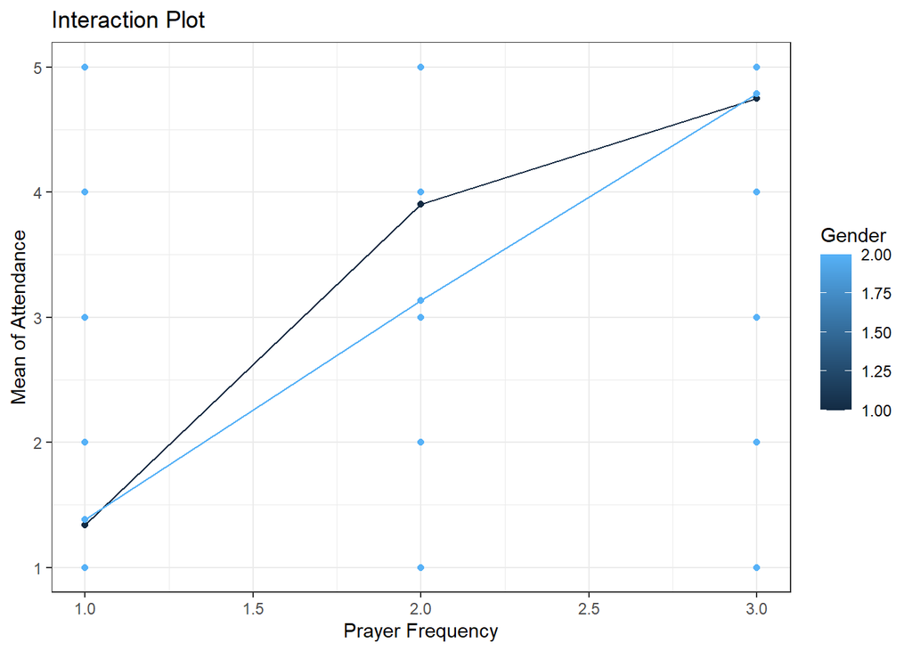

Fig. 1. Line plot. Effect of gender and prayer frequency on mean of attendance.

[output not shown]

Fig. 2. F table for Prayer Frequency.

[output not shown]

Fig. 3. Linear Model table for Prayer and Gender.